# Films

Rose Campos, Jessenia Contreras

2024-04-04

## Introduction

Have you ever seen a film, and thought to yourself “Oh my god! This movie is a masterpiece!” Only to look it up and see a 2.4 IMB rating? Through this report, we take a data set of fifty beloved ‘popular’ films containing a quantitative measure of level of enjoyment, appreciation, and deemed classical-ness to create a comprehensive analysis that takes into account the film’s genre and the demographic of viewers. The data we used was gathered from a sample pool of 282 participants of which only 69 where male. The participant pool had an age range of 19 to 37 with the median age range being 22.25. The ethnicity distribution was 39% was Caucasian, 31.5% was Asian, ~13.5% was Hispanic, ~2% was African American, and ~12% Unknown. The remaining percentage is filled by Pacific Islanders and other ethnicity. This data was collected by attendees of the University of Texas at Austin in 2017 for a Journal of Media Psychology publication. The goal of the original source was to determine how enjoyment and appreciation could impact viewers aggregate appraisals. The data used is available for download and review at [Data.World](https://data.world/robertjoellewis/enjoyment-versus-appreciation-ratings-of-50-popular-films).

## Data Preparation

Below, we load in the packages we’ll be using to analyse our data.

```r
#Packages loading to use
library(tidyverse) ##Loaded for dplyr and to 'clean' data
library(ggplot2) ##Loaded for plotting
library(dplyr) ##Loaded for computer issues
library(gridExtra) #Loaded to arrange plots
library(yaml)
library(patchwork)
library(reshape2)
```

Now, we’ll read in the data from its .CSV file into our project and save it to the variable **raw_data**.

```r
##Read in data and save it to variable raw_data
raw_data <- read.csv(file = "popular_film_data.csv")
glimpse (raw_data)
```

```
## Rows: 50
## Columns: 65
## $ BoxOfficeMojo        <int> 0, 0, 0, 0, 0, 1, 0, 0, 0, 0, 0, 0, 0, 0, 0, 0, 0…
## $ IMDB                 <int> 1, 1, 1, 1, 1, 1, 1, 1, 1, 1, 1, 1, 1, 1, 1, 1, 1…
## $ OriginalOrder        <int> 1, 2, 3, 4, 5, 6, 7, 8, 9, 10, 11, 12, 13, 14, 15…
## $ FilmName             <chr> "Shawshank_Classic", "Godfather_Classic", "Godfat…
## $ Classic              <dbl> 0.87, 0.91, 0.74, 0.83, 0.49, 0.62, 0.70, 0.84, 0…
## $ ImDb_A               <int> 1, 1, 1, 1, 1, 1, 1, 1, 1, 1, 1, 1, 1, 1, 1, 1, 1…
## $ Boxofficemojo_A      <int> 0, 0, 0, 0, 0, 1, 0, 0, 1, 0, 0, 0, 0, 0, 0, 0, 0…
## $ Year                 <int> 1994, 1972, 1974, 1994, 1966, 2008, 1957, 1993, 2…
## $ InflatedBudget       <chr> "$38,705,260.07", "$32,966,408.46", "$60,592,133.…
## $ TotalGross           <chr> "$28,341,469.00", "$245,066,411.00", "$47,542,841…
## $ InflatedGross        <chr> "$43,878,557.13", "$1,346,493,234.29", "$221,594,…
## $ V15                  <chr> "Shawshank", "Godfather", "Godfather p 2", "Pulp …
## $ Check_enj_label      <chr> "Shawshank_enj", "Godfather_enj", "Godfather p 2_…
```

[output cut: 52 more lines]

## Cleaning and Mutating Data

Some of the data contained in the the variables *InflatedBudget*, *InflatedGross*, and *TotalGross* have symbols such as “$” and “,”. These symbols cause the the information in them to be read as characters rather than as integers. We use gsub to remove these symbols.

```r
#To remove "$" and "," from InflatedBudget
raw_data$InflatedBudget <-  gsub("\\$","", raw_data$InflatedBudget)
raw_data$InflatedBudget <-  as.numeric(gsub(",","", raw_data$InflatedBudget))

#To remove "$" and "," from InflatedGross
raw_data$InflatedGross <-  gsub("\\$","", raw_data$InflatedGross)
raw_data$InflatedGross <-  as.numeric(gsub(",","", raw_data$InflatedGross))

#To remove "$" and "," from TotalGross
raw_data$TotalGross <-  gsub("\\$","", raw_data$TotalGross)
raw_data$TotalGross <-  as.numeric(gsub(",","", raw_data$TotalGross))

#To View our now changed data.
glimpse (raw_data)
```

```
## Rows: 50
## Columns: 65
## $ BoxOfficeMojo        <int> 0, 0, 0, 0, 0, 1, 0, 0, 0, 0, 0, 0, 0, 0, 0, 0, 0…
## $ IMDB                 <int> 1, 1, 1, 1, 1, 1, 1, 1, 1, 1, 1, 1, 1, 1, 1, 1, 1…
## $ OriginalOrder        <int> 1, 2, 3, 4, 5, 6, 7, 8, 9, 10, 11, 12, 13, 14, 15…
## $ FilmName             <chr> "Shawshank_Classic", "Godfather_Classic", "Godfat…
## $ Classic              <dbl> 0.87, 0.91, 0.74, 0.83, 0.49, 0.62, 0.70, 0.84, 0…
## $ ImDb_A               <int> 1, 1, 1, 1, 1, 1, 1, 1, 1, 1, 1, 1, 1, 1, 1, 1, 1…
## $ Boxofficemojo_A      <int> 0, 0, 0, 0, 0, 1, 0, 0, 1, 0, 0, 0, 0, 0, 0, 0, 0…
## $ Year                 <int> 1994, 1972, 1974, 1994, 1966, 2008, 1957, 1993, 2…
## $ InflatedBudget       <dbl> 38705260, 32966408, 60592133, 1238568, 8501703, 1…
## $ TotalGross           <dbl> 28341469, 245066411, 47542841, 213928762, 2510000…
## $ InflatedGross        <dbl> 43878557, 1346493234, 221594012, 331206735, 17782…
## $ V15                  <chr> "Shawshank", "Godfather", "Godfather p 2", "Pulp …
## $ Check_enj_label      <chr> "Shawshank_enj", "Godfather_enj", "Godfather p 2_…
```

[output cut: 52 more lines]

Now, we also see that our data has a *Proportion_male* column. Let’s mutate that so we can also see the female ratio and store it in the variable *Proportion_female*.

```r
#Mutating for new column stored in Proportion_female
raw_data <- raw_data |> mutate (Proportion_female = (1 - Proportion_male))

#To view our data with the new variable.
glimpse(raw_data)
```

```
## Rows: 50
## Columns: 66
## $ BoxOfficeMojo        <int> 0, 0, 0, 0, 0, 1, 0, 0, 0, 0, 0, 0, 0, 0, 0, 0, 0…
## $ IMDB                 <int> 1, 1, 1, 1, 1, 1, 1, 1, 1, 1, 1, 1, 1, 1, 1, 1, 1…
## $ OriginalOrder        <int> 1, 2, 3, 4, 5, 6, 7, 8, 9, 10, 11, 12, 13, 14, 15…
## $ FilmName             <chr> "Shawshank_Classic", "Godfather_Classic", "Godfat…
## $ Classic              <dbl> 0.87, 0.91, 0.74, 0.83, 0.49, 0.62, 0.70, 0.84, 0…
## $ ImDb_A               <int> 1, 1, 1, 1, 1, 1, 1, 1, 1, 1, 1, 1, 1, 1, 1, 1, 1…
## $ Boxofficemojo_A      <int> 0, 0, 0, 0, 0, 1, 0, 0, 1, 0, 0, 0, 0, 0, 0, 0, 0…
## $ Year                 <int> 1994, 1972, 1974, 1994, 1966, 2008, 1957, 1993, 2…
## $ InflatedBudget       <dbl> 38705260, 32966408, 60592133, 1238568, 8501703, 1…
## $ TotalGross           <dbl> 28341469, 245066411, 47542841, 213928762, 2510000…
## $ InflatedGross        <dbl> 43878557, 1346493234, 221594012, 331206735, 17782…
## $ V15                  <chr> "Shawshank", "Godfather", "Godfather p 2", "Pulp …
## $ Check_enj_label      <chr> "Shawshank_enj", "Godfather_enj", "Godfather p 2_…
```

[output cut: 53 more lines]

## Data Analysis

We’ll start by learning about our data has. What is the year range of it? How many films make up our data?

```r
#What is the release year range of the films in our dataset?
range(raw_data$Year)
```

```
## [1] 1942 2013
```

```r
#How many entries make up our dataset?
quantity_films <- nrow(raw_data)
quantity_films
```

```
## [1] 50
```

We wanted to learn more about the films. First we are looking into how many films of each genre there are?

```r
genre_total <- rbind(cbind(genre = "Comedy", raw_data %>% filter(Comedy == 1) %>% summarise(sumG = sum(Comedy == 1))),
    cbind(genre = "Drama", raw_data %>% filter(Drama == 1) %>% summarise(sumG = sum(Drama == 1))),
    cbind(genre = "Western", raw_data %>% filter(Western == 1) %>% summarise(sumG = sum(Western == 1))),
    cbind(genre = "Action", raw_data %>% filter(Action == 1) %>% summarise(sumG = sum(Action == 1))),
    cbind(genre = "Biography", raw_data %>% filter(Biography == 1) %>% summarise(sumG = sum(Biography == 1))),
    cbind(genre = "History", raw_data %>% filter(History == 1) %>% summarise(sumG = sum(History == 1))),
    cbind(genre = "Adventure", raw_data %>% filter(Adventure == 1) %>% summarise(sumG = sum(Adventure == 1))),
    cbind(genre = "Fantasy", raw_data %>% filter(Fantasy == 1) %>% summarise(sumG = sum(Fantasy == 1))),
    cbind(genre = "Mystery", raw_data %>% filter(Mystery == 1) %>% summarise(sumG = sum(Mystery == 1))),
    cbind(genre = "SciFi", raw_data %>% filter(SciFi == 1) %>% summarise(sumG = sum(SciFi == 1))),
    cbind(genre = "Romance", raw_data %>% filter(Romance == 1) %>% summarise(sumG = sum(Romance == 1))),
    cbind(genre = "Thriller", raw_data %>% filter(Thriller == 1) %>% summarise(sumG = sum(Thriller == 1))),
    cbind(genre = "Crime", raw_data %>% filter(Crime == 1) %>% summarise(sumG = sum(Crime == 1))),
    cbind(genre = "War", raw_data %>% filter(War == 1) %>% summarise(sumG = sum(War == 1))),
    cbind(genre = "Family", raw_data %>% filter(Family == 1) %>% summarise(sumG = sum(Family == 1))),
    cbind(genre = "Animation", raw_data %>% filter(Animation == 1) %>% summarise(sumG = sum(Animation == 1))))%>% arrange(desc(sumG))

genre_total
```

```
##        genre sumG
## 1  Adventure   27
## 2      Drama   20
## 3    Fantasy   17
## 4     Action   16
## 5      Crime   11
## 6      SciFi    6
## 7     Family    6
## 8   Thriller    5
## 9     Comedy    3
## 10   Romance    3
## 11 Animation    3
## 12   Western    2
## 13 Biography    2
## 14   Mystery    2
## 15   History    1
## 16       War    1
```

To make this information more visual, we’ll plot it below.

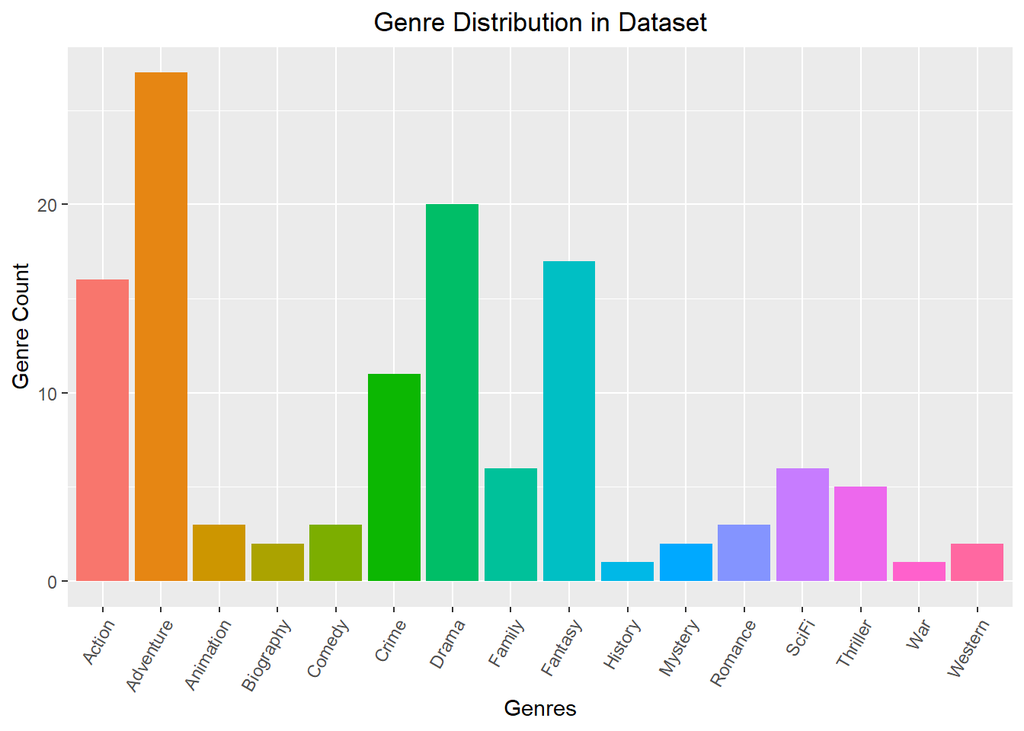

```r
Genre_Count_Plot <- ggplot(genre_total) + geom_bar(mapping = aes(genre, sumG, fill = genre), stat = "identity", position = "dodge", show.legend = FALSE) + labs(x = 'Genres', y = 'Genre Count', title = 'Genre Distribution in Dataset') + theme(axis.text.x = element_text(angle = 60, hjust = 1)) + theme(plot.title = element_text(hjust = 0.5))
Genre_Count_Plot
```

Clearly, most of the entries in our dataset are of adventure films, and drama films. There isn’t an even distribution of the genres in the dataset - this might skewer the remaining of our analysis towards this those genres. Another thing to keep in mind is that each film can have more than one genre.

Now, we’ll look at the year distribution of our film entries. Does the data contain multiple films per year? Is so, what is the count for each year?

```r
 raw_data|>group_by(Year) |> summarise(Movie_Count = n()) |> arrange(desc(Movie_Count))
```

```
## # A tibble: 30 × 2
##     Year Movie_Count
##    <int>       <int>
##  1  1994           4
##  2  2010           4
##  3  2012           4
##  4  1999           3
##  5  2011           3
##  6  1993           2
##  7  1995           2
##  8  2001           2
##  9  2002           2
## 10  2003           2
## # ℹ 20 more rows
```

The above is arranged by to be descending by amount of movies present of each year but it is difficult to see this overall. To give visibility to this distribution we create a plot based on the above. First, we save it to a variable.

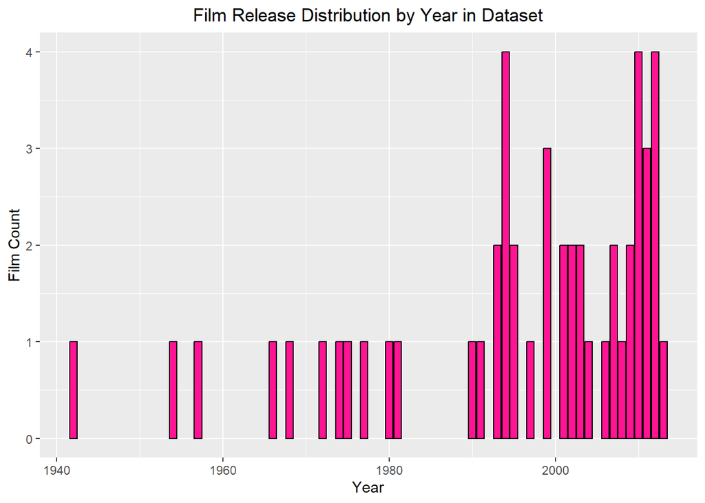

```r
#Storing the code to the "count_movieby_year" variable.

count_movieby_year <-  raw_data|>group_by(Year) |> summarise(Movie_Count = n()) |> arrange(desc(Movie_Count))
ggplot(count_movieby_year, aes(x = Year, y = Movie_Count)) + geom_col(fill = "deeppink", color = "black") + labs(x = 'Year', y = 'Film Count', title = 'Film Release Distribution by Year in Dataset') + theme(plot.title = element_text(hjust = 0.5))
```

Next, we wanted to find the average budget for each year. We want to see if the year had an impact on the budget.

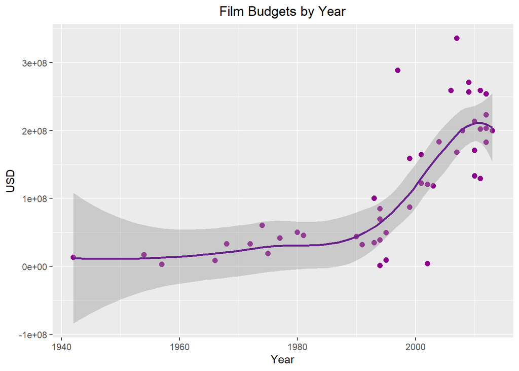

```r
Avg_Budget_by_Year <- raw_data |> group_by(Year)|> summarise(InflatedBudget) |> ggplot(aes(Year,InflatedBudget)) +geom_point(size = 2.2, color = "darkmagenta") + geom_smooth(color = "darkorchid4")+labs(x = 'Year', y = 'USD', title = 'Film Budgets by Year') + theme(plot.title = element_text(hjust = 0.5))

Avg_Budget_by_Year
```

From the graph we can see there is a trend. The graphs tell us that the closer we get to the present the budget increases for films. There is a rapid increase in budgets from the year 1990’s to the year 2010’s.

Now we want to see, if what the relation is between a films budget and gross income. First we focus on the plotting the *InflatedGross* income.

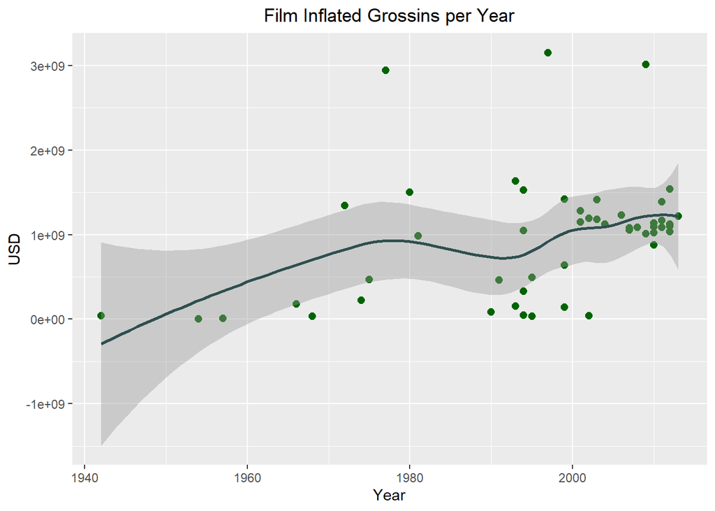

```r
Avg_Grossing_by_Year <- raw_data |> group_by(Year) |> summarise(InflatedGross) |> ggplot(aes(Year,InflatedGross)) +geom_point(size = 2.2, color = "darkgreen") + geom_smooth(color = "darkslategray") + labs(x = 'Year', y = 'USD', title = 'Film Inflated Grossins per Year') + theme(plot.title = element_text(hjust = 0.5))

Avg_Grossing_by_Year
```

It’s a little hard to compare the *InflatedGross* income and the *InflatedBudget* in two graphs so lets display this information together so we can analyse it.

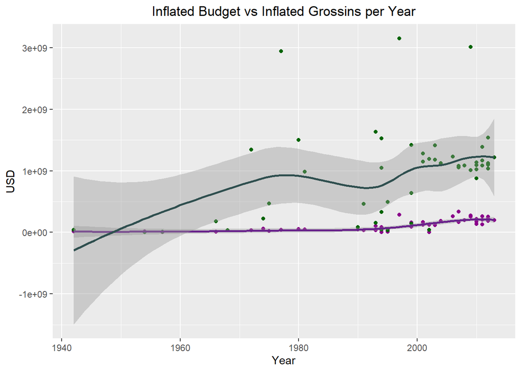

```r
#raw_data |> group_by(Year)|> ggplot(aes(Year,InflatedGross, InflatedBudget, color = )) +geom_point() + geom_smooth(method = 'loess', formula = 'y~x')

raw_data |> group_by(Year) |> ggplot(aes(x=Year))+geom_point(aes(y=InflatedBudget),color = "darkmagenta") + geom_point(aes(y=InflatedGross), color = "darkgreen") + geom_smooth(aes(y=InflatedBudget), color = "darkorchid4") +labs(x = "Year", y = "USD") + geom_smooth(aes(y=InflatedGross), color = "darkslategray") + labs(x = 'Year', y = 'USD', title = 'Inflated Budget vs Inflated Grossins per Year') + theme(plot.title = element_text(hjust = 0.5))
```

The graph is not wrong, but both variables have a different y-scale, with the difference being of millions of dollars. Due to this difference we can’t see how the budget changes with the years. To overcome this, we’ll stack the plots.

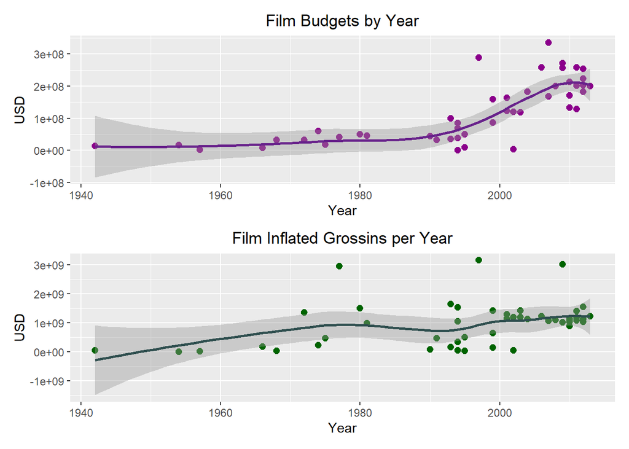

```r
plot_1 <- (Avg_Budget_by_Year / Avg_Grossing_by_Year)
plot_1
```

Since the graphs are now separate from each other, we can see the data in more details. We can tell the difference in each category more clearly.

First we wanted to see which year had the highest budget.

```r
raw_data |> slice_max(InflatedBudget, n = 10) |> select(FilmName, Year, InflatedGross)
```

```
##                          FilmName Year InflatedGross
## 1           PCAtWorldsEnd_Classic 2007    1079129111
## 2                 Titanic_Classic 1997    3153199889
## 3       HPHalfBloodPrince_Classic 2009    1012374878
## 4    PCA\xcaDeadMansChest_Classic 2006    1227668445
## 5  PCA\xcaOnStrangerTides_Classic 2011    1083688899
## 6                  Avatar_Classic 2009    3014400460
## 7         DarkKnightRises_Classic 2012    1100705685
## 8             TheAvengers_Classic 2012    1541373834
## 9               ToyStory3_Classic 2010    1133732648
## 10        AliceWonderland_Classic 2010    1093525450
```

Then we wanted to look for the year the had the highest Gross.

```r
raw_data |> slice_max(InflatedGross, n = 10) |> select(FilmName, Year,InflatedGross)
```

```
##                     FilmName Year InflatedGross
## 1            Titanic_Classic 1997    3153199889
## 2             Avatar_Classic 2009    3014400460
## 3           StarWars_Classic 1977    2939933749
## 4       JurassicPark_Classic 1993    1634773761
## 5        TheAvengers_Classic 2012    1541373834
## 6           LionKing_Classic 1994    1528832656
## 7          StarWars5_Classic 1980    1499045455
## 8          StarWarsI_Classic 1999    1419296470
## 9       LRReturnKing_Classic 2003    1411841983
## 10 HPDeathlyHallows2_Classic 2011    1390228199
```

From this data we can confirm that the movies with the highest budget doesn’t mean that it will make the highest gross.

We know the answers to these questions for individual film entries - now we’ll answer them for the genre category. Here we are looking at the budget,gross, female proportions and the male proportions.

```r
#We'll arrange the code to output what we need to see.
genreGrossBudget <- (rbind(cbind(genre = "Comedy", raw_data %>% filter(Comedy == 1) %>% summarise(meangross = mean(InflatedGross), meanBudget = mean(InflatedBudget), Male_Proportion = Proportion_male, Female_Proportion = Proportion_female, Femalegross = ((mean(Proportion_female))*meangross), Malegross = ((mean(Proportion_male))*meangross))),
      cbind(genre = "Drama", raw_data %>% filter(Drama == 1) %>% summarise(meangross = mean(InflatedGross),meanBudget = mean(InflatedBudget),  Male_Proportion = Proportion_male, Female_Proportion = Proportion_female, Femalegross = ((mean(Proportion_female))*meangross), Malegross = ((mean(Proportion_male))*meangross))),
      cbind(genre = "Western", raw_data %>% filter(Western == 1) %>% summarise(meangross = mean(InflatedGross),meanBudget = mean(InflatedBudget),  Male_Proportion = Proportion_male, Female_Proportion = Proportion_female, Femalegross = ((mean(Proportion_female))*meangross), Malegross = ((mean(Proportion_male))*meangross))),
      cbind(genre = "Action", raw_data %>% filter(Action == 1) %>% summarise(meangross = mean(InflatedGross),meanBudget = mean(InflatedBudget),  Male_Proportion = Proportion_male, Female_Proportion = Proportion_female, Femalegross = ((mean(Proportion_female))*meangross), Malegross = ((mean(Proportion_male))*meangross))),
     cbind(genre = "Biography", raw_data %>% filter(Biography == 1) %>% summarise(meangross = mean(InflatedGross),meanBudget = mean(InflatedBudget), Malegross = ((mean(Proportion_male))*meangross), Male_Proportion = Proportion_male, Female_Proportion = Proportion_female, Femalegross = ((mean(Proportion_female))*meangross), Malegross = ((mean(Proportion_male))*meangross))),
    cbind(genre = "History", raw_data %>% filter(History == 1) %>% summarise(meangross = mean(InflatedGross),meanBudget = mean(InflatedBudget),  Male_Proportion = Proportion_male, Female_Proportion = Proportion_female, Femalegross = ((mean(Proportion_female))*meangross), Malegross = ((mean(Proportion_male))*meangross))),
    cbind(genre = "Adventure", raw_data %>% filter(Adventure == 1) %>% summarise(meangross = mean(InflatedGross),meanBudget = mean(InflatedBudget),  Male_Proportion = Proportion_male, Female_Proportion = Proportion_female, Femalegross = ((mean(Proportion_female))*meangross), Malegross = ((mean(Proportion_male))*meangross))),
        cbind(genre = "Fantasy", raw_data %>% filter(Fantasy == 1) %>% summarise(meangross = mean(InflatedGross),meanBudget = mean(InflatedBudget),  Male_Proportion = Proportion_male, Female_Proportion = Proportion_female, Femalegross = ((mean(Proportion_female))*meangross), Malegross = ((mean(Proportion_male))*meangross))),
    cbind(genre = "Mystery", raw_data %>% filter(Mystery == 1) %>% summarise(meangross = mean(InflatedGross),meanBudget = mean(InflatedBudget),  Male_Proportion = Proportion_male, Female_Proportion = Proportion_female, Femalegross = ((mean(Proportion_female))*meangross), Malegross = ((mean(Proportion_male))*meangross))),
    cbind(genre = "SciFi", raw_data %>% filter(SciFi == 1) %>% summarise(meangross = mean(InflatedGross),meanBudget = mean(InflatedBudget),  Male_Proportion = Proportion_male, Female_Proportion = Proportion_female, Femalegross = ((mean(Proportion_female))*meangross), Malegross = ((mean(Proportion_male))*meangross))),
    cbind(genre = "Romance", raw_data %>% filter(Romance == 1) %>% summarise(meangross = mean(InflatedGross),meanBudget = mean(InflatedBudget),  Male_Proportion = Proportion_male, Female_Proportion = Proportion_female, Femalegross = ((mean(Proportion_female))*meangross), Malegross = ((mean(Proportion_male))*meangross))),
    cbind(genre = "Thriller", raw_data %>% filter(Drama == 1) %>% summarise(meangross = mean(InflatedGross),meanBudget = mean(InflatedBudget),  Male_Proportion = Proportion_male, Female_Proportion = Proportion_female, Femalegross = ((mean(Proportion_female))*meangross), Malegross = ((mean(Proportion_male))*meangross))),
    cbind(genre = "Crime", raw_data %>% filter(Crime == 1) %>% summarise(meangross = mean(InflatedGross),meanBudget = mean(InflatedBudget),  Male_Proportion = Proportion_male, Female_Proportion = Proportion_female, Femalegross = ((mean(Proportion_female))*meangross), Malegross = ((mean(Proportion_male))*meangross))),
    cbind(genre = "War", raw_data %>% filter(War == 1) %>% summarise(meangross = mean(InflatedGross),meanBudget = mean(InflatedBudget),  Male_Proportion = Proportion_male, Female_Proportion = Proportion_female, Femalegross = ((mean(Proportion_female))*meangross), Malegross = ((mean(Proportion_male))*meangross))),
    cbind(genre = "Family", raw_data %>% filter(Family == 1) %>% summarise(meangross = mean(InflatedGross),meanBudget = mean(InflatedBudget),  Male_Proportion = Proportion_male, Female_Proportion = Proportion_female, Femalegross = ((mean(Proportion_female))*meangross), Malegross = ((mean(Proportion_male))*meangross))),
    cbind(genre = "Animation", raw_data %>% filter(Animation == 1) %>% summarise(meangross = mean(InflatedGross),meanBudget = mean(InflatedBudget), Male_Proportion = Proportion_male, Female_Proportion = Proportion_female, Femalegross = ((mean(Proportion_female))*meangross), Malegross = ((mean(Proportion_male))*meangross)))) %>% arrange(desc(meanBudget)))
genreGrossBudget
```

```
##         genre  meangross meanBudget Male_Proportion Female_Proportion
## 1      Family 1097910750  188821479            0.24              0.76
## 2      Family 1097910750  188821479            0.27              0.73
## 3      Family 1097910750  188821479            0.27              0.73
## 4      Family 1097910750  188821479            0.27              0.73
## 5      Family 1097910750  188821479            0.28              0.72
## 6      Family 1097910750  188821479            0.27              0.73
## 7      Action 1374979940  184161982            0.31              0.69
## 8      Action 1374979940  184161982            0.43              0.57
## 9      Action 1374979940  184161982            0.30              0.70
## 10     Action 1374979940  184161982            0.37              0.63
## 11     Action 1374979940  184161982            0.42              0.58
## 12     Action 1374979940  184161982            0.48              0.52
## 13     Action 1374979940  184161982            0.30              0.70
## 14     Action 1374979940  184161982            0.38              0.62
```

[output cut: 267 more lines]

#Over all, what genre cost more to produce on average? How much did that category produce in grossing?

```r
genreGrossBudget |> slice(which(meanBudget ==max(meanBudget) | meanBudget == min(meanBudget))) |> distinct()
```

```
##    genre  meangross meanBudget Male_Proportion Female_Proportion Femalegross
## 1 Family 1097910750  188821479            0.24              0.76   805134550
## 2 Family 1097910750  188821479            0.27              0.73   805134550
## 3 Family 1097910750  188821479            0.28              0.72   805134550
## 4    War   40555510   13399819            0.33              0.67    27172192
##   Malegross
## 1 292776200
## 2 292776200
## 3 292776200
## 4  13383318
```

We want to see all of that information in a way that is visually apealing and easy to understand. We’ll create a graphs for each of these and arrange them side-by-side.

[figure not shown]

```r
meanBudget_Genre <- (ggplot(genreGrossBudget) + geom_bar(mapping = aes(genre, meanBudget, fill = genre), stat = "identity") + labs(x = 'Genre', y = 'USD', title = 'Mean Budget per Genre') + theme(axis.text.x = element_text(angle = 60, hjust = 1)) + theme(plot.title = element_text(hjust = 0.5)))

meanGross_Genre <- ggplot(genreGrossBudget) + geom_bar(mapping = aes(genre, meangross, fill = genre), stat = "identity", show.legend = FALSE) + labs(x = 'Genre', y = 'USD', title = 'Mean Grossings per Genre') + theme(axis.text.x = element_text(angle = 60, hjust = 1)) + theme(plot.title = element_text(hjust = 0.5))

grid.arrange(meanBudget_Genre, meanGross_Genre, nrow = 1)
```

Now we’ll plot each genre, and their grossing by sex. We visually want to see if there was a distinction between sex by genres. Since most of our participants was mostly females.

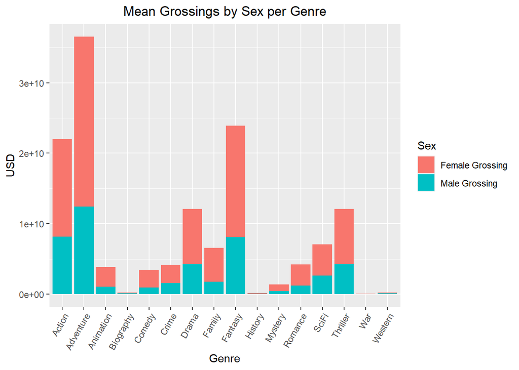

```r
#genreGrossBudget <- genreGrossBudget |> mutate ( Gross_Female = (as.numeric(genreGrossBudget$meangross) * as.numeric(raw_data$Proportion_female)))

genreGrossBudget |> pivot_longer(cols = ends_with("alegross"), names_to = "Sex", values_to = "proportion") |> ggplot() + geom_col(aes(x = genre, y = proportion, fill = Sex)) + labs(x = 'Genre', y = 'USD', title = 'Mean Grossings by Sex per Genre') + theme(axis.text.x = element_text(angle = 60, hjust = 1)) + theme(plot.title = element_text(hjust = 0.5)) + scale_fill_discrete(labels = c("Female Grossing", "Male Grossing"))
```

```r
genre_enj <- rbind(cbind(genre = "Comedy", raw_data %>% filter(Comedy == 1) %>% summarise(meanenj = mean(Enjoyment))),
    cbind(genre = "Drama", raw_data %>% filter(Drama == 1) %>% summarise(meanenj = mean(Enjoyment))),
    cbind(genre = "Western", raw_data %>% filter(Western == 1) %>% summarise(meanenj = mean(Enjoyment))),
    cbind(genre = "Action", raw_data %>% filter(Action == 1) %>% summarise(meanenj = mean(Enjoyment))),
    cbind(genre = "Biography", raw_data %>% filter(Biography == 1) %>% summarise(meanenj = mean(Enjoyment))),
    cbind(genre = "History", raw_data %>% filter(History == 1) %>% summarise(meanenj = mean(Enjoyment))),
    cbind(genre = "Adventure", raw_data %>% filter(Adventure == 1) %>% summarise(meanenj = mean(Enjoyment))),
    cbind(genre = "Fantasy", raw_data %>% filter(Fantasy == 1) %>% summarise(meanenj = mean(Enjoyment))),
    cbind(genre = "Mystery", raw_data %>% filter(Mystery == 1) %>% summarise(meanenj = mean(Enjoyment))),
    cbind(genre = "SciFi", raw_data %>% filter(SciFi == 1) %>% summarise(meanenj = mean(Enjoyment))),
    cbind(genre = "Romance", raw_data %>% filter(Romance == 1) %>% summarise(meanenj = mean(Enjoyment))),
    cbind(genre = "Thriller", raw_data %>% filter(Thriller == 1) %>% summarise(meanenj = mean(Enjoyment))),
    cbind(genre = "Crime", raw_data %>% filter(Crime == 1) %>% summarise(meanenj = mean(Enjoyment))),
    cbind(genre = "War", raw_data %>% filter(War == 1) %>% summarise(meanenj = mean(Enjoyment))),
    cbind(genre = "Family", raw_data %>% filter(Family == 1) %>% summarise(meanenj = mean(Enjoyment))),
    cbind(genre = "Animation", raw_data %>% filter(Animation == 1) %>% summarise(meanenj = mean(Enjoyment))))%>% arrange(desc(meanenj))

genre_enj |> slice(which(meanenj ==max(meanenj) | meanenj == min(meanenj))) |> distinct()
```

```
##       genre meanenj
## 1 Animation    6.42
## 2   History    4.23
```

```r
genre_app <- rbind(cbind(genre = "Comedy", raw_data %>% filter(Comedy == 1) %>% summarise(meanapp = mean(Appreciation))),
    cbind(genre = "Drama", raw_data %>% filter(Drama == 1) %>% summarise(meanapp = mean(Appreciation))),
    cbind(genre = "Western", raw_data %>% filter(Western == 1) %>% summarise(meanapp = mean(Appreciation))),
    cbind(genre = "Action", raw_data %>% filter(Action == 1) %>% summarise(meanapp = mean(Appreciation))),
    cbind(genre = "Biography", raw_data %>% filter(Biography == 1) %>% summarise(meanapp = mean(Appreciation))),
    cbind(genre = "History", raw_data %>% filter(History == 1) %>% summarise(meanapp = mean(Appreciation))),
    cbind(genre = "Adventure", raw_data %>% filter(Adventure == 1) %>% summarise(meanapp = mean(Appreciation))),
    cbind(genre = "Fantasy", raw_data %>% filter(Fantasy == 1) %>% summarise(meanapp = mean(Appreciation))),
    cbind(genre = "Mystery", raw_data %>% filter(Mystery == 1) %>% summarise(meanapp = mean(Appreciation))),
    cbind(genre = "SciFi", raw_data %>% filter(SciFi == 1) %>% summarise(meanapp = mean(Appreciation))),
    cbind(genre = "Romance", raw_data %>% filter(Romance == 1) %>% summarise(meanapp = mean(Appreciation))),
    cbind(genre = "Thriller", raw_data %>% filter(Thriller == 1) %>% summarise(meanapp = mean(Appreciation))),
    cbind(genre = "Crime", raw_data %>% filter(Crime == 1) %>% summarise(meanapp = mean(Appreciation))),
    cbind(genre = "War", raw_data %>% filter(War == 1) %>% summarise(meanapp = mean(Appreciation))),
    cbind(genre = "Family", raw_data %>% filter(Family == 1) %>% summarise(meanapp = mean(Appreciation))),
    cbind(genre = "Animation", raw_data %>% filter(Animation == 1) %>% summarise(meanapp = mean(Appreciation))))%>% arrange(desc(meanapp))

genre_app |> slice(which(meanapp ==max(meanapp) | meanapp == min(meanapp))) |> distinct()
```

```
##     genre  meanapp
## 1 History 6.367521
## 2 Western 4.364370
```

We’ll now visually compare enjoyment and appreciation by genre.

```r
combined_df <- merge(genre_app, genre_enj, by="genre", all=TRUE)
combined_df.long<-melt(combined_df)
```

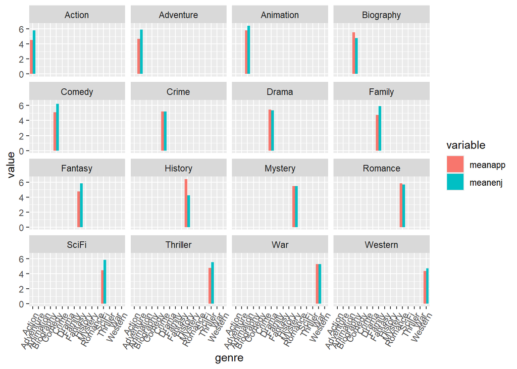

```r
ggplot(combined_df.long,aes(genre,value, fill=variable))+
     geom_bar(stat="identity",position="dodge")+ theme(axis.text.x = element_text(angle = 60, hjust = 1))+facet_wrap(~genre)
```

Lastly we are comparing the top appreciation/enjoyment to the top gross.

```r
raw_data |> slice_max(Appreciation, n = 10)|> select(FilmName,Appreciation, Enjoyment)
```

```
##                  FilmName Appreciation Enjoyment
## 1  SchindlersList_Classic     6.367521  4.230000
## 2     ForrestGump_Classic     6.303972  6.160000
## 3       Shawshank_Classic     6.217822  5.508251
## 4        LionKing_Classic     6.005979  6.450000
## 5         Titanic_Classic     5.830357  5.640000
## 6       ToyStory3_Classic     5.760360  6.350000
## 7     CuckoosNest_Classic     5.743590  5.170000
## 8       FightClub_Classic     5.648810  5.820000
## 9       Inception_Classic     5.617284  5.980000
## 10    FindingNemo_Classic     5.560332  6.460000
```

```r
raw_data |> slice_max(Enjoyment, n = 10) |> select(FilmName, Enjoyment, Appreciation)
```

```
##                     FilmName Enjoyment Appreciation
## 1        FindingNemo_Classic  6.460000     5.560332
## 2           LionKing_Classic  6.450000     6.005979
## 3          ToyStory3_Classic  6.350000     5.760360
## 4        ForrestGump_Classic  6.160000     6.303972
## 5   HPSorcerersStone_Classic  6.100000     5.043519
## 6  HPDeathlyHallows2_Classic  6.080000     5.371622
## 7           StarWars_Classic  6.070000     4.991736
## 8        TheAvengers_Classic  6.060000     4.000000
## 9         DarkKnight_Classic  6.048759     5.320035
## 10   DarkKnightRises_Classic  5.990000     5.179563
```

```r
raw_data |> slice_max(InflatedGross, n = 10) |> select(FilmName, InflatedGross, Appreciation, Enjoyment)
```

```
##                     FilmName InflatedGross Appreciation Enjoyment
## 1            Titanic_Classic    3153199889     5.830357      5.64
## 2             Avatar_Classic    3014400460     5.245989      5.86
## 3           StarWars_Classic    2939933749     4.991736      6.07
## 4       JurassicPark_Classic    1634773761     4.625259      5.87
## 5        TheAvengers_Classic    1541373834     4.000000      6.06
## 6           LionKing_Classic    1528832656     6.005979      6.45
## 7          StarWars5_Classic    1499045455     4.964286      5.85
## 8          StarWarsI_Classic    1419296470     4.512821      5.50
## 9       LRReturnKing_Classic    1411841983     4.994048      5.78
## 10 HPDeathlyHallows2_Classic    1390228199     5.371622      6.08
```

We can see that the top appreciation have different films compare to the top enjoyment. Now we want to see if any of the films from our finding will differentiate from the top gross category.

```r
raw_data |> slice_max(InflatedGross, n = 10) |> select(FilmName, InflatedGross, Appreciation, Enjoyment)
```

```
##                     FilmName InflatedGross Appreciation Enjoyment
## 1            Titanic_Classic    3153199889     5.830357      5.64
## 2             Avatar_Classic    3014400460     5.245989      5.86
## 3           StarWars_Classic    2939933749     4.991736      6.07
## 4       JurassicPark_Classic    1634773761     4.625259      5.87
## 5        TheAvengers_Classic    1541373834     4.000000      6.06
## 6           LionKing_Classic    1528832656     6.005979      6.45
## 7          StarWars5_Classic    1499045455     4.964286      5.85
## 8          StarWarsI_Classic    1419296470     4.512821      5.50
## 9       LRReturnKing_Classic    1411841983     4.994048      5.78
## 10 HPDeathlyHallows2_Classic    1390228199     5.371622      6.08
```

The top gross film was Titanic which place 5th in the appreciation top 10 but not in enjoyment top 10. In conclusion gross doesn’t mean that it will be the best film. It just mean that it made the most money. Just watch the films that you enjoy and appreciate. Its all opinions anyways.